# Master en Big Data. Fundamentos Matemáticos del Análisis de Datos (FMAD).

Tarea 1

Pablo Sanz Caperote

Curso 2021-22. Última actualización: 2021-09-17

# Instrucciones preliminares

- Empieza abriendo el proyecto de RStudio correspondiente a tu repositorio personal de la asignatura.
- En todas las tareas tendrás que repetir un proceso como el descrito en la sección *Repite los pasos Creando un fichero Rmarkdown para esta práctica* de la *Práctica00*. Puedes releer la sección *Practicando la entrega de las Tareas* de esa misma práctica para recordar el procedimiento de entrega.

# Ejercicio 0

- Si no has hecho los *Ejercicios* de la *Práctica00* (págs. 12 y 13) hazlos ahora y añádelos a esta tarea. Si ya los has hecho y entregado a través de GitHub no hace falta que hagas nada.
1. Usando la función `sample` crea un vector `dado_honesto` con 100 números del 1 al 6. Haz una tabla de frecuencias absolutas (de dos maneras, con `table` y `dplyr`) y una tabla de frecuencias relativas.

```r
library(tidyverse)
dado_honesto = sample(6, 100, TRUE)
table(dado_honesto)
```

```
## dado_honesto
##  1  2  3  4  5  6
## 20 11 13 20 19 17
```

```r
df = data.frame(dado_honesto)
df %>%
  count(dado_honesto)
```

```
##   dado_honesto  n
## 1            1 20
## 2            2 11
## 3            3 13
## 4            4 20
## 5            5 19
## 6            6 17
```

```r
signif(prop.table(table(dado_honesto)), 2)
```

```
## dado_honesto
##    1    2    3    4    5    6
## 0.20 0.11 0.13 0.20 0.19 0.17
```

2. A continuación crea un nuevo vector `dado_cargado` de manera que la probabilidad de que el número elegido valga 6 sea el doble que la probabilidad de elegir cualquiera de los cinco números restantes. Lee la ayuda de `sample` si lo necesitas. De nuevo, haz tablas de frecuencias absolutas y relativas de este segundo vector.

```r
dado_cargado = sample(6, 100, replace = TRUE,  prob = c(1/7, 1/7, 1/7, 1/7, 1/7, 2/7))
dado_cargado
```

```
##   [1] 1 1 2 1 6 4 5 6 4 5 2 5 2 6 6 3 2 3 6 6 1 3 4 6 6 6 5 5 3 6 5 6 2 3 6 1 4
##  [38] 6 6 6 6 4 2 4 4 1 4 2 4 5 3 5 6 6 6 4 6 6 6 4 3 2 3 3 1 6 1 1 3 2 1 1 6 6
##  [75] 2 3 6 6 6 1 3 6 6 3 1 5 1 1 4 2 3 3 3 5 5 2 2 6 6 6
```

```r
table(dado_cargado)
```

```
## dado_cargado
##  1  2  3  4  5  6
## 15 13 16 12 11 33
```

```r
df = data.frame(dado_cargado)
df %>%
  count(dado_cargado)
```

```
##   dado_cargado  n
## 1            1 15
## 2            2 13
## 3            3 16
## 4            4 12
## 5            5 11
## 6            6 33
```

```r
signif(prop.table(table(dado_cargado)), 2)
```

```
## dado_cargado
##    1    2    3    4    5    6
## 0.15 0.13 0.16 0.12 0.11 0.33
```

3. Utiliza las funciones `rep` y `seq` para crear tres vectores `v1`, `v2` y `v3` con estos elementos respectivamente:

   ```
   4, 4, 4, 4, 3, 3, 3, 3, 2, 2, 2, 2, 1, 1, 1, 1

   1, 2, 2, 3, 3, 3, 4, 4, 4, 4, 5, 5, 5, 5, 5

   1, 2, 3, 4, 1, 2, 3, 4, 1, 2, 3, 4, 1, 2, 3, 4
   ```

```r
rep(4:1, each = 4)
```

```
##  [1] 4 4 4 4 3 3 3 3 2 2 2 2 1 1 1 1
```

```r
rep(1:5, seq(1:5))
```

```
##  [1] 1 2 2 3 3 3 4 4 4 4 5 5 5 5 5
```

```r
rep(seq(1,4), 4)
```

```
##  [1] 1 2 3 4 1 2 3 4 1 2 3 4 1 2 3 4
```

```r
mpg2 = mpg %>%
  filter(mpg$class == "pickup") %>%
  select(starts_with("c"))
mpg2
```

```
## # A tibble: 33 × 3
##      cyl   cty class
##    <int> <int> <chr>
##  1     6    15 pickup
##  2     6    14 pickup
##  3     6    13 pickup
##  4     6    14 pickup
##  5     8    14 pickup
##  6     8    14 pickup
##  7     8     9 pickup
##  8     8    11 pickup
##  9     8    11 pickup
## 10     8    12 pickup
## # … with 23 more rows
```

```r
library(haven)
census <- read_dta("census.dta")
```

#5.1

```r
poblaciones <- census %>%
  group_by(region) %>%
  summarise(poblacion_total = sum(pop), n=n())
poblaciones
```

```
## # A tibble: 4 × 3
##        region poblacion_total     n
##     <dbl+lbl>           <dbl> <int>
## 1 1 [NE]             49135283     9
## 2 2 [N Cntrl]        58865670    12
## 3 3 [South]          74734029    16
## 4 4 [West]           43172490    13
```

#5.2

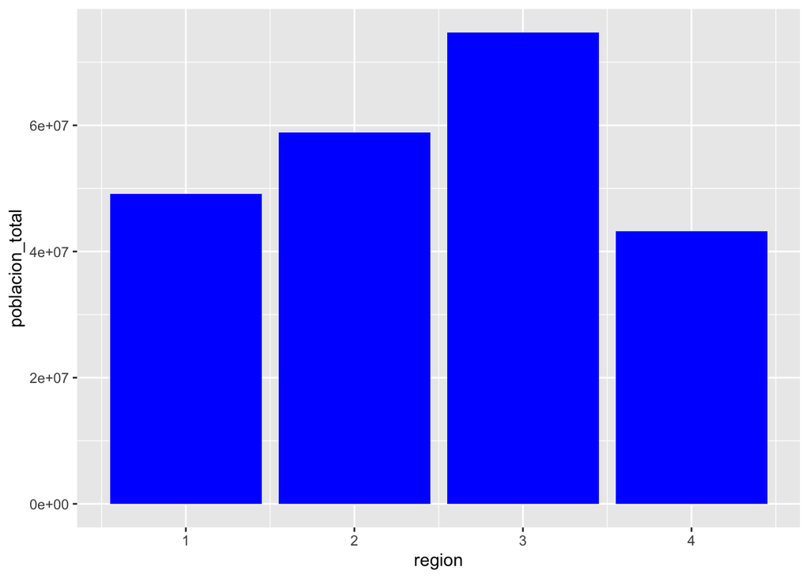

```r
ggplot(poblaciones, aes(x = region, y = poblacion_total)) +
  geom_bar(fill = 'blue', stat = "identity")
```

#5.3

```r
census[order(census$pop, decreasing = TRUE), ]
```

```
## # A tibble: 50 × 12
##    state       region    pop poplt5 pop5_17 pop18p pop65p popurban medage  death
##    <chr>    <dbl+lbl>  <dbl>  <dbl>   <dbl>  <dbl>  <dbl>    <dbl>  <dbl>  <dbl>
##  1 Califor… 4 [West]  2.37e7 1.71e6 4680558 1.73e7 2.41e6 21607606   29.9 186428
##  2 New York 1 [NE]    1.76e7 1.14e6 3551938 1.29e7 2.16e6 14858068   31.9 171769
##  3 Texas    3 [South] 1.42e7 1.17e6 3137045 9.92e6 1.37e6 11333017   28.2 108019
##  4 Pennsyl… 1 [NE]    1.19e7 7.47e5 2375838 8.74e6 1.53e6  8220851   32.1 123261
##  5 Illinois 2 [N Cnt… 1.14e7 8.42e5 2400796 8.18e6 1.26e6  9518039   29.9 102230
##  6 Ohio     2 [N Cnt… 1.08e7 7.87e5 2307170 7.70e6 1.17e6  7918259   29.9  98268
##  7 Florida  3 [South] 9.75e6 5.70e5 1789412 7.39e6 1.69e6  8212385   34.7 104190
##  8 Michigan 2 [N Cnt… 9.26e6 6.85e5 2066873 6.51e6 9.12e5  6551551   28.8  75102
##  9 New Jer… 1 [NE]    7.36e6 4.63e5 1527572 5.37e6 8.60e5  6557377   32.2  68762
## 10 N. Caro… 3 [South] 5.88e6 4.04e5 1253659 4.22e6 6.03e5  2822852   29.6  48426
## # … with 40 more rows, and 2 more variables: marriage <dbl>, divorce <dbl>
```

#5.4

```r
matrimonios_exito <- census %>%
  select(state, divorce, marriage) %>%
  mutate(porcentaje_exito = divorce/marriage) %>%
  arrange(porcentaje_exito)
matrimonios_exito
```

```
## # A tibble: 50 × 4
##    state         divorce marriage porcentaje_exito
##    <chr>           <dbl>    <dbl>            <dbl>
##  1 Nevada          13842   114333            0.121
##  2 S. Carolina     13595    53915            0.252
##  3 S. Dakota        2811     8800            0.319
##  4 N. Dakota        2142     6094            0.351
##  5 Pennsylvania    34922    93673            0.373
##  6 Hawaii           4438    11856            0.374
##  7 Maryland        17494    46278            0.378
##  8 Massachusetts   17873    46273            0.386
##  9 Virginia        23615    60210            0.392
## 10 Minnesota       15371    37641            0.408
## # … with 40 more rows
```

#5.5

```r
estados_envejecidos <- census %>%
  select(state, pop, medage, pop65p) %>%
  mutate( porcentaje_mayores = pop65p/pop) %>%
  arrange(desc(medage)) %>%
  select(state, medage, porcentaje_mayores) %>%
  top_n(10)
estados_envejecidos
```

```
## # A tibble: 10 × 3
##    state         medage porcentaje_mayores
##    <chr>          <dbl>              <dbl>
##  1 Florida         34.7              0.173
##  2 Pennsylvania    32.1              0.129
##  3 Rhode Island    31.8              0.134
##  4 Massachusetts   31.2              0.127
##  5 Missouri        30.9              0.132
##  6 Arkansas        30.6              0.137
##  7 Kansas          30.1              0.130
##  8 Iowa            30                0.133
##  9 Nebraska        29.7              0.131
## 10 S. Dakota       28.9              0.132
```

#5.6

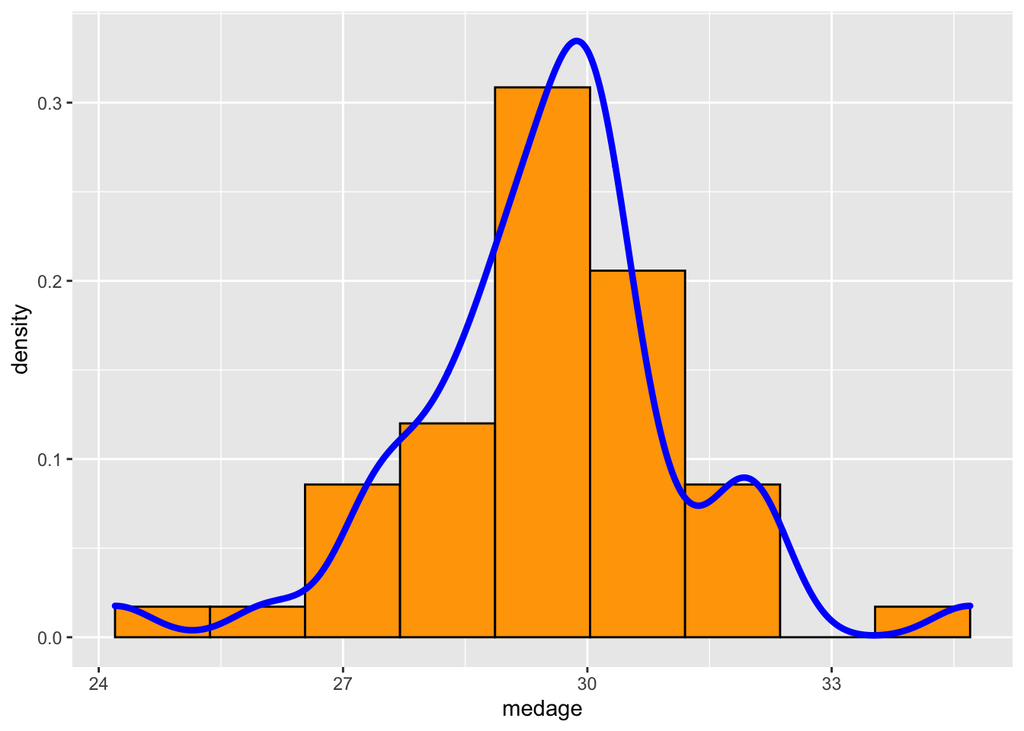

```r
cortes = seq(min(census$medage), max(census$medage), length.out = 10)
ggplot(census, aes(x = medage)) +
    geom_histogram(aes(y=stat(density)),
                   breaks = cortes, fill = "orange", color="black")  +
    geom_density(color="blue", size=1.5)
```

$\quad$ #Práctica 1

# Ejercicio 1. Análisis exploratorio de un conjunto de datos y operaciones con dplyr.

- Vamos a utilizar el conjunto de datos contenido en el fichero (es un enlace):  
  cholesterol.csv  
  Los datos proceden de un estudio realizado en la *University of Virginia School of Medicine* que investiga la prevalencia de la obesidad, la diabetes y otros factores de riesgo cardiovascular. Se puede encontrar más información sobre el fichero en este enlace:  
  https://biostat.app.vumc.org/wiki/pub/Main/DataSets/diabetes.html
- Carga el conjunto de datos en un data.frame de R llamado `chlstrl`.

```r
library(readr)
chlsrtl <- read_csv("cholesterol.csv")
```

- Empezaremos por información básica sobre el conjunto de datos. Cuántas observaciones contiene, cuáles son las variables y de qué tipos,…

```r
num_filas <- nrow(chlsrtl)
cat("El número de pacientes es", num_filas)
```

```
## El número de pacientes es 403
```

```r
num_col <- ncol(chlsrtl)
cat("El numero de columnas es", num_col)
```

```
## El numero de columnas es 7
```

```r
"A continuación se muestran los nombres de las columnas y sus tipos:"
```

```
## [1] "A continuación se muestran los nombres de las columnas y sus tipos:"
```

```r
sapply(chlsrtl, class)
```

```
##        chol         age      gender      height      weight       waist
##   "numeric"   "numeric" "character"   "numeric"   "numeric"   "numeric"
##         hip
##   "numeric"
```

```r
"Por último hacemos un resumen de todo lo visto anteriormente"
```

```
## [1] "Por último hacemos un resumen de todo lo visto anteriormente"
```

```r
str(chlsrtl)
```

```
## spec_tbl_df [403 × 7] (S3: spec_tbl_df/tbl_df/tbl/data.frame)
##  $ chol  : num [1:403] 203 165 228 78 249 248 195 227 177 263 ...
##  $ age   : num [1:403] 46 29 58 67 64 34 30 37 45 55 ...
##  $ gender: chr [1:403] "female" "female" "female" "male" ...
##  $ height: num [1:403] 62 64 61 67 68 71 69 59 69 63 ...
##  $ weight: num [1:403] 121 218 256 119 183 190 191 170 166 202 ...
##  $ waist : num [1:403] 29 46 49 33 44 36 46 34 34 45 ...
##  $ hip   : num [1:403] 38 48 57 38 41 42 49 39 40 50 ...
##  - attr(*, "spec")=
##   .. cols(
##   ..   chol = col_double(),
##   ..   age = col_double(),
##   ..   gender = col_character(),
##   ..   height = col_double(),
##   ..   weight = col_double(),
##   ..   waist = col_double(),
##   ..   hip = col_double()
##   .. )
##  - attr(*, "problems")=<externalptr>
```

- Asegúrate de comprobar si hay datos ausentes y localízalos en la tabla. Hacemos unas comprobaciones anidades aunque no sea lo más eficiente para ir paso a paso

```r
if(any(is.na(chlsrtl))){
  print("Hay algún valor vacío.")
  print("En la siguiente tabla los mostramos")
  valores_vacios <- chlsrtl[rowSums(is.na(chlsrtl)) > 0,]
  valores_vacios

} else{
  print("No existen valores vacíos")
}
```

```
## [1] "Hay algún valor vacío."
## [1] "En la siguiente tabla los mostramos"
```

```
## # A tibble: 9 × 7
##    chol   age gender height weight waist   hip
##   <dbl> <dbl> <chr>   <dbl>  <dbl> <dbl> <dbl>
## 1    NA    48 male       68    100    27    33
## 2   145    38 female     NA    125    31    35
## 3   218    51 female     NA    215    42    53
## 4   115    58 male       69     NA    30    37
## 5   173    40 female     NA    130    37    38
## 6   214    44 female     NA    190    38    44
## 7   300    34 female     NA    160    40    47
## 8   158    30 female     62    142    NA    NA
## 9   192    51 male       65    146    NA    NA
```

- El análisis exploratorio (numérico y gráfico) debe cubrir todos los tipos de variable de la tabla. Es decir, que al menos debes estudiar una variable por cada tipo de variable presente en la tabla. El análisis debe contener, al menos:
  - Para las variables cuantittativas (continuas o discretas).  
    Resumen numérico básico.  
    Gráficas (las adecuadas, a ser posible más de un tipo de gráfico).
  - Variables categóricas (factores).  
    Tablas de frecuencia (absolutas y relativas).  
    Gráficas (diagrama de barras).

```r
clear_chlsrtl <- chlsrtl[rowSums(is.na(chlsrtl)) == 0,]
clear_chlsrtl
```

```
## # A tibble: 394 × 7
##     chol   age gender height weight waist   hip
##    <dbl> <dbl> <chr>   <dbl>  <dbl> <dbl> <dbl>
##  1   203    46 female     62    121    29    38
##  2   165    29 female     64    218    46    48
##  3   228    58 female     61    256    49    57
##  4    78    67 male       67    119    33    38
##  5   249    64 male       68    183    44    41
##  6   248    34 male       71    190    36    42
##  7   195    30 male       69    191    46    49
##  8   227    37 male       59    170    34    39
##  9   177    45 male       69    166    34    40
## 10   263    55 female     63    202    45    50
## # … with 384 more rows
```

Tomaremos como ejemplo de variable cuantitativa discreta la columna “chol” ya que considero que los pacientes se pueden agrupar en rangos de colesterol y no es necesario saber exactamente cuál es su valor.

- En un primer resumen calculamos la media, el máximo y el mínimo.

```r
data.frame(media = mean(clear_chlsrtl$chol), maximo = max(clear_chlsrtl$chol), minimo = min(clear_chlsrtl$chol))
```

```
##      media maximo minimo
## 1 208.2208    443     78
```

- Ahora vamos a hacerlo de una forma más sencilla, aplicando la función “Summary” que además muestra nás estadísticas.

```r
summary(chlsrtl$chol)
```

```
##    Min. 1st Qu.  Median    Mean 3rd Qu.    Max.    NA's
##    78.0   179.0   204.0   207.8   230.0   443.0       1
```

- Luego, dividimos el conjunto de datos en 10 secciones de la misma longitud y creamos una tabla para representar la frecuencia absoluta de cada grupo.

```r
datos_cortados = cut(clear_chlsrtl$chol, breaks = 10)
tabla_rangos = table(datos_cortados)
tabla_rangos
```

```
## datos_cortados
## (77.6,114]  (114,151]  (151,188]  (188,224]  (224,260]  (260,297]  (297,334]
##          1         29         98        147         74         31          9
##  (334,370]  (370,406]  (406,443]
##          3          1          1
```

- Calculamos también la tabla de frecuencias relativas

```r
signif(prop.table(tabla_rangos), 3)
```

```
## datos_cortados
## (77.6,114]  (114,151]  (151,188]  (188,224]  (224,260]  (260,297]  (297,334]
##    0.00254    0.07360    0.24900    0.37300    0.18800    0.07870    0.02280
##  (334,370]  (370,406]  (406,443]
##    0.00761    0.00254    0.00254
```

- Con la tabla de rangos creada anteriormente elaboramos un diagrama de barras. Aunque sea parecido a la creación de un histograma hay diferencia.

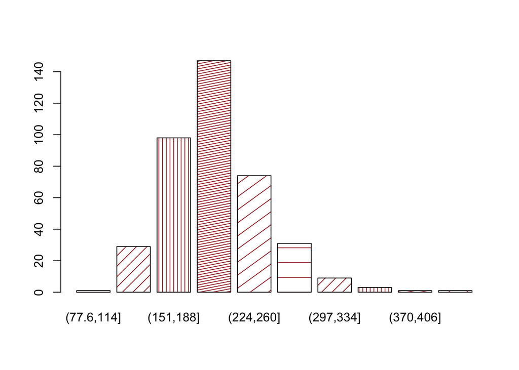

```r
barplot(height=tabla_rangos, density=c(5,10,20,30,7) , angle=c(0,45,90,11,36) , col="brown")
```

+ A continuación creamos un boxplot

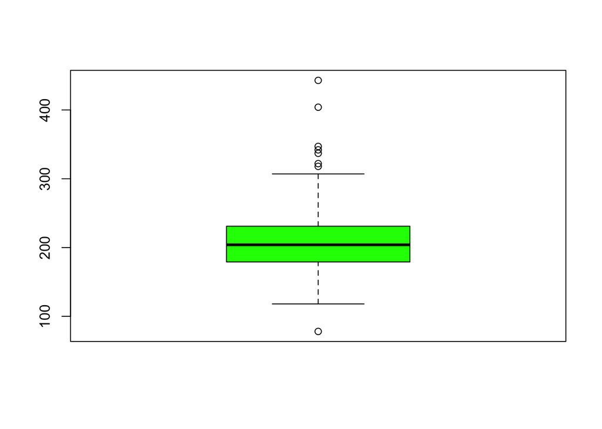

```r
boxplot(clear_chlsrtl$chol, col="green")
```

Tomaremos como ejemplo de variable cuantitativa continua la columna “waist”. + Al igual que antes calculamos la media, el máximo y el mínimo “a mano”.

```r
data.frame(media = mean(clear_chlsrtl$waist), maximo = max(clear_chlsrtl$waist), minimo = min(clear_chlsrtl$waist))
```

```
##      media maximo minimo
## 1 37.95178     56     26
```

- Ahora vamos a hacerlo de una forma más sencilla, aplicando la función “Summary” que además muestra nás estadísticas.

```r
summary(chlsrtl$waist)
```

```
##    Min. 1st Qu.  Median    Mean 3rd Qu.    Max.    NA's
##    26.0    33.0    37.0    37.9    41.0    56.0       2
```

- Aunque hayamos tomado esta variable como variable cuantitativa continua, vamos a hacer una tabla de frecuencias absolutas porque como se ha podido ver anteriormente, el rango de la variable no es muy amplio y así probamos.

```r
clear_chlsrtl %>%
  count(waist)
```

```
## # A tibble: 29 × 2
##    waist     n
##    <dbl> <int>
##  1    26     2
##  2    28     7
##  3    29    11
##  4    30     9
##  5    31    21
##  6    32    21
##  7    33    28
##  8    34    23
##  9    35    20
## 10    36    25
## # … with 19 more rows
```

- Creamos un histograma con la curva de densidad

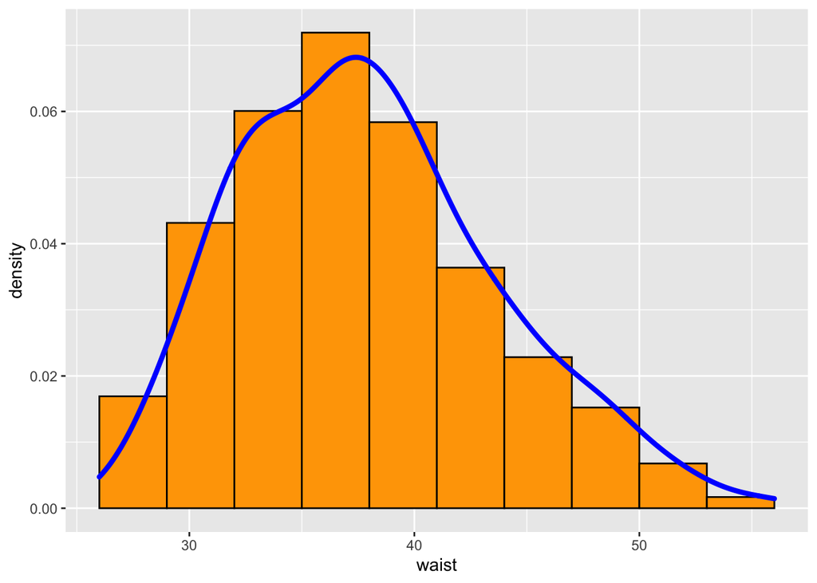

```r
cortes = seq(min(clear_chlsrtl$waist), max(clear_chlsrtl$waist), length.out = 11)
ggplot(data = clear_chlsrtl, mapping = aes(x = waist)) +
  geom_histogram(breaks = cortes, aes(y=stat(density)),
                   fill = "orange", color="black") +
  geom_density(color="blue", size=1.5)
```

+ Antes de calcular el boxplot, vamos a calcular qué puntos se considerarían atípicos. Para ello usamos lo siguiente:

```r
unname(quantile(clear_chlsrtl$waist, probs = c(1/4, 3/4)) + c(-1, 1) * 1.5 * IQR(clear_chlsrtl$waist))
```

```
## [1] 21.625 52.625
```

- Ahora calculamos el gráfico y comprobamos lo visto anteriormente

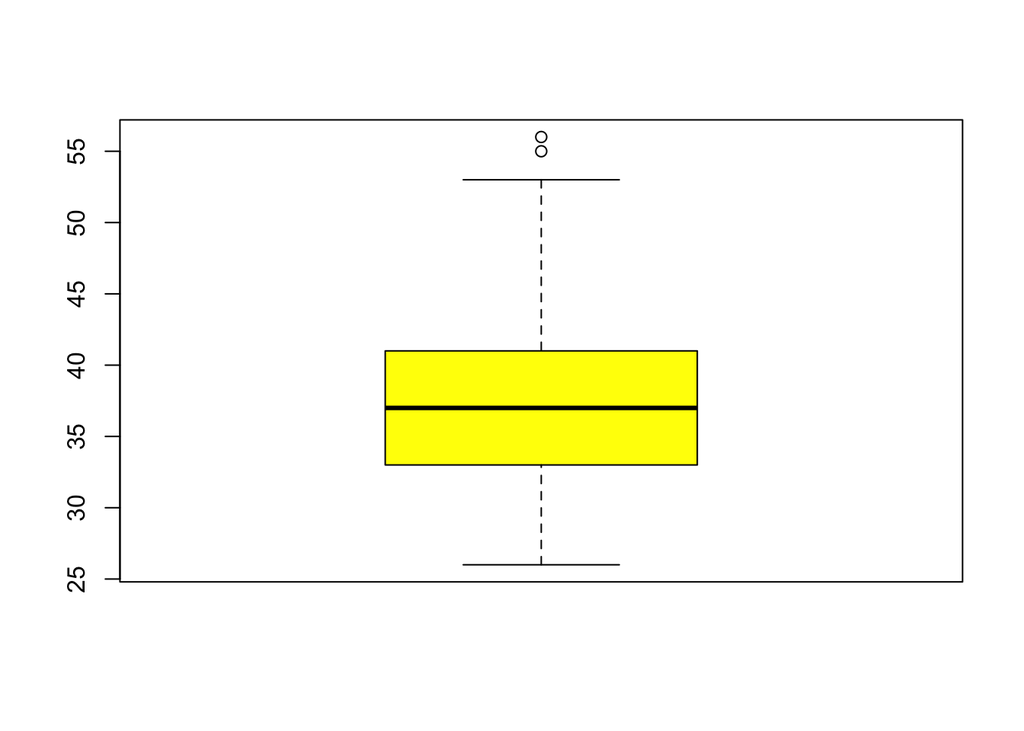

```r
boxplot(clear_chlsrtl$waist, col="yellow")
```

Como variable categórica vamos a usar la variable “gender”. + Calculamos la frecuencia absoluta

```r
table(clear_chlsrtl$gender)
```

```
##
## female   male
##    228    166
```

```r
signif(prop.table(table(clear_chlsrtl$gender)),3)
```

```
##
## female   male
##  0.579  0.421
```

- Dibujamos primero un gráfico de barras

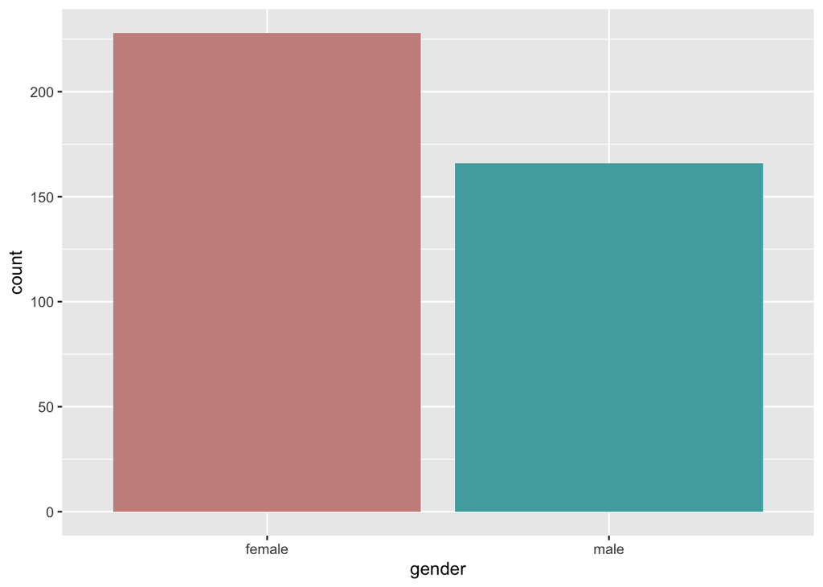

```r
ggplot(clear_chlsrtl, aes(x=gender, fill=as.factor(gender))) +
  geom_bar( ) +
  scale_fill_hue(c = 40) +
  theme(legend.position="none")
```

+ Dibujamos también un gráfico circular

[figure not shown]

```r
ggplot(clear_chlsrtl, aes(x = "", y = gender, fill = gender)) +
  geom_col() +
  coord_polar(theta = "y")
```

- Los valores de `height` y `weight` están en pulgadas (inches) y libras (pounds) respectivamente. Una libra son $\approx$ 0.454kg y una pulgada son $\approx$ 0.0254m. Usa dplyr para convertir esas columnas a metros y kilogramos respectivamente. Las nuevas columnas deben llamarse igual que las originales.

```r
chlsrtl2 <- chlsrtl %>%
  mutate(weight = weight*0.454, height = height*0.0254)
chlsrtl2
```

```
## # A tibble: 403 × 7
##     chol   age gender height weight waist   hip
##    <dbl> <dbl> <chr>   <dbl>  <dbl> <dbl> <dbl>
##  1   203    46 female   1.57   54.9    29    38
##  2   165    29 female   1.63   99.0    46    48
##  3   228    58 female   1.55  116.     49    57
##  4    78    67 male     1.70   54.0    33    38
##  5   249    64 male     1.73   83.1    44    41
##  6   248    34 male     1.80   86.3    36    42
##  7   195    30 male     1.75   86.7    46    49
##  8   227    37 male     1.50   77.2    34    39
##  9   177    45 male     1.75   75.4    34    40
## 10   263    55 female   1.60   91.7    45    50
## # … with 393 more rows
```

- Ahora usa esos valores de `height` y `weight` para añadir una nueva columna llamada BMI, definida mediante:
  $$BMI = \dfrac{weight}{height^2}$$

```r
chlsrtl2 <- chlsrtl2 %>%
  mutate(BMI = weight/(height)**2)
chlsrtl2
```

```
## # A tibble: 403 × 8
##     chol   age gender height weight waist   hip   BMI
##    <dbl> <dbl> <chr>   <dbl>  <dbl> <dbl> <dbl> <dbl>
##  1   203    46 female   1.57   54.9    29    38  22.2
##  2   165    29 female   1.63   99.0    46    48  37.5
##  3   228    58 female   1.55  116.     49    57  48.4
##  4    78    67 male     1.70   54.0    33    38  18.7
##  5   249    64 male     1.73   83.1    44    41  27.8
##  6   248    34 male     1.80   86.3    36    42  26.5
##  7   195    30 male     1.75   86.7    46    49  28.2
##  8   227    37 male     1.50   77.2    34    39  34.4
##  9   177    45 male     1.75   75.4    34    40  24.5
## 10   263    55 female   1.60   91.7    45    50  35.8
## # … with 393 more rows
```

(se divide por el cuadrado de la altura).

- Crea una nueva columna llamada `ageGroup` dividiendo la edad en los siguientes tres niveles:

```
(10,40], (40,70], (70,100]
```

```
# A tibble: 403 × 9
    chol   age gender height weight waist   hip   BMI ageGroup
   <dbl> <dbl> <chr>   <dbl>  <dbl> <dbl> <dbl> <dbl> <fct>
 1   203    46 female   1.57   54.9    29    38  22.2 (40,70]
 2   165    29 female   1.63   99.0    46    48  37.5 (10,40]
 3   228    58 female   1.55  116.     49    57  48.4 (40,70]
 4    78    67 male     1.70   54.0    33    38  18.7 (40,70]
 5   249    64 male     1.73   83.1    44    41  27.8 (40,70]
 6   248    34 male     1.80   86.3    36    42  26.5 (10,40]
 7   195    30 male     1.75   86.7    46    49  28.2 (10,40]
 8   227    37 male     1.50   77.2    34    39  34.4 (10,40]
 9   177    45 male     1.75   75.4    34    40  24.5 (40,70]
10   263    55 female   1.60   91.7    45    50  35.8 (40,70]
# … with 393 more rows
```

- Usando `dplyr` calcula cuántas observaciones hay en cada nivel de `ageGroup` (indicación: usa `group_by`). Ahora, usando aquellas observaciones que corresponden a mujeres, ¿cuál es la media del nivel de colesterol y de BMI en cada uno de esos grupos de edad?

```r
chlsrtl2 %>%
  group_by(ageGroup) %>%
  summarise(n = n())
```

```
## # A tibble: 3 × 2
##   ageGroup     n
##   <fct>    <int>
## 1 (10,40]    160
## 2 (40,70]    207
## 3 (70,100]    36
```

```r
chlsrtl2 %>%
  group_by(ageGroup) %>%
  filter(gender == "female") %>%
  summarise(media_col = mean(chol, na.rm =  TRUE), media_BMI = mean(BMI, na.rm = TRUE))
```

```
## # A tibble: 3 × 3
##   ageGroup media_col media_BMI
##   <fct>        <dbl>     <dbl>
## 1 (10,40]       189.      30.5
## 2 (40,70]       221.      30.3
## 3 (70,100]      230.      29.4
```

# Ejercicio 2: Funciones de R.

- Crea una función de R llamada `cambiosSigno` que dado un vector `x` de números enteros no nulos, como

  ```r
  set.seed(2019)
  x = sample(c(-1, 1), 9, replace = TRUE) * sample(1:20, 9, replace = TRUE)
  cat(paste0(x, sep=", "))
  ```

  ```
  -12,  -19,  9,  -13,  -14,  -17,  8,  -19,  -14,
  ```

  calcule cuántos cambios de signo ha habido. Es decir, cuántas veces el signo de un elemento es distinto del signo del elemento previo. Por ejemplo, en el vector anterior hay 4 cambios de signo (en las posiciones 3, 4, 7 y 8).

```r
cambiosSignos = function(v){
  cambios = 0
  for (i in 2:length(v)){
    if(sign(v[[i-1]]) != sign(v[[i]])){
      cambios = cambios + 1
    }
  }
  cambios
}
```

```r
for (i in 1:5){
  x = sample(c(-1, 1), 9, replace = TRUE) * sample(1:20, 9, replace = TRUE)
  print("El vector es:")
  print(x)
  cat(cat("El número de cambios de signos del vector es:", cambiosSignos(x)), '\n')
  cat(cat("Las posiciones de los cambios de signos son:", cambiosSignoPos(x)), '\n')
}
```

```
## [1] "El vector es:"
## [1]   5  -1  14  -7   6  -6 -17 -16   6
## El número de cambios de signos del vector es: 6
## Las posiciones de los cambios de signos son: 2 3 4 5 6 9
## [1] "El vector es:"
## [1] -14  17 -16  -2  17 -13   1   9 -12
## El número de cambios de signos del vector es: 6
## Las posiciones de los cambios de signos son: 2 3 5 6 7 9
## [1] "El vector es:"
## [1]  -2 -16  13  -6 -15  13  10  -8  -7
## El número de cambios de signos del vector es: 4
## Las posiciones de los cambios de signos son: 3 4 6 8
## [1] "El vector es:"
## [1]  13  18  -2   8   7   3 -12 -14 -12
## El número de cambios de signos del vector es: 3
## Las posiciones de los cambios de signos son: 3 4 7
## [1] "El vector es:"
## [1]  10 -19 -19  19   2  -2  -4  18   2
## El número de cambios de signos del vector es: 4
## Las posiciones de los cambios de signos son: 2 4 6 8
```

```
También se valorará que incluyas en el código como usar `sample` para generar vectores aleatorios de 20 enteros *no nulos* (el vector debe poder tomar valores positivos y negativos).
```

# Ejercicio 3. R4DS.

Es recomendable que esta semana del curso hagas al menos una lectura somera de los Capítulos 1 a 5 de [R for Data Science (R4DS), de H. Wickham](https://r4ds.had.co.nz/index.html), con énfasis especial en los Capítulos 3 y 5 (los capítulos 1, 2 y 4 son muy breves). Los siguientes apartados pretenden motivar esa lectura y por eso mismo pueden resultar un poco más laboriosos.

- Haz el [ejercicio 6 de la Sección 3.6.1 de R4DS](https://r4ds.had.co.nz/data-visualisation.html#exercises-3).

```r
g1 <- ggplot(data = mpg, mapping = aes(x = displ, y = hwy)) +
  geom_point() +
  geom_smooth(se = FALSE)
```

```r
g2<- ggplot(data = mpg, mapping = aes(x = displ, y = hwy, group = drv)) +
  geom_point() +
  geom_smooth(method = 'loess', se = FALSE)
```

```r
g3<- ggplot(data = mpg, mapping = aes(x = displ, y = hwy, color = drv)) +
  geom_point() +
  geom_smooth(method = 'loess', se = FALSE)
```

```r
g4 <- ggplot(data = mpg, mapping = aes(x = displ, y = hwy)) +
  geom_point(mapping = aes(color = drv)) +
  geom_smooth(method = 'loess', se = FALSE)
```

```r
g5 <- ggplot(data = mpg, mapping = aes(x = displ, y = hwy, group = drv)) +
  geom_point(mapping = aes(color = drv)) +
  geom_smooth(mapping = aes(linetype = drv), method = 'loess', se = FALSE)
```

```r
g6 <- ggplot(data = mpg, mapping = aes(x = displ, y = hwy)) +
  geom_point(size = 3, colour = "white") +
  geom_point(aes(colour = drv), size = 1)
```

```r
library(grid)
library(gridExtra)
```

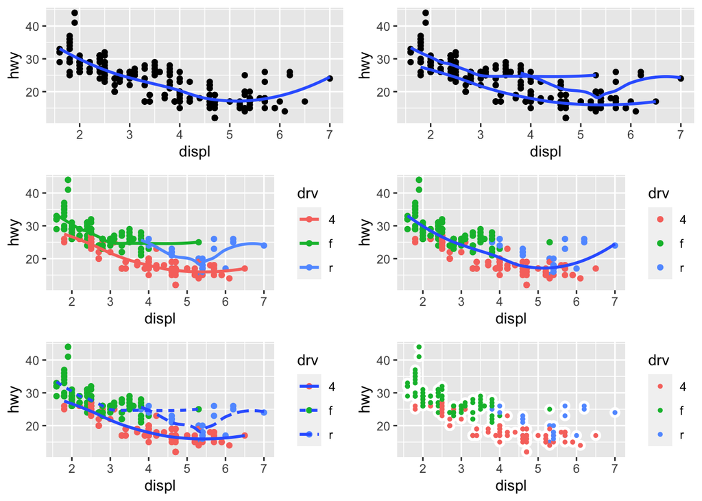

```r
grid.arrange(g1, g2, g3, g4, g5, g6, nrow = 3)
```

- Haz el [ejercicio 1 de la Sección 5.2.4 de R4DS](https://r4ds.had.co.nz/transform.html#exercises-8).
- Lo primero que tenemos que hacer es cargar la librería

```r
library(nycflights13)
```

- Vuelos con un retraso de la llegada de 2 o más horas

```r
flights %>%
  filter(arr_delay >= 120)
```

```
## # A tibble: 10,200 × 19
##     year month   day dep_time sched_dep_time dep_delay arr_time sched_arr_time
##    <int> <int> <int>    <int>          <int>     <dbl>    <int>          <int>
##  1  2013     1     1      811            630       101     1047            830
##  2  2013     1     1      848           1835       853     1001           1950
##  3  2013     1     1      957            733       144     1056            853
##  4  2013     1     1     1114            900       134     1447           1222
##  5  2013     1     1     1505           1310       115     1638           1431
##  6  2013     1     1     1525           1340       105     1831           1626
##  7  2013     1     1     1549           1445        64     1912           1656
##  8  2013     1     1     1558           1359       119     1718           1515
##  9  2013     1     1     1732           1630        62     2028           1825
## 10  2013     1     1     1803           1620       103     2008           1750
## # … with 10,190 more rows, and 11 more variables: arr_delay <dbl>,
## #   carrier <chr>, flight <int>, tailnum <chr>, origin <chr>, dest <chr>,
## #   air_time <dbl>, distance <dbl>, hour <dbl>, minute <dbl>, time_hour <dttm>
```

- Volados a Houston

```r
flights %>%
  filter(dest == "IAH" | dest == "HOU")
```

```
## # A tibble: 9,313 × 19
##     year month   day dep_time sched_dep_time dep_delay arr_time sched_arr_time
##    <int> <int> <int>    <int>          <int>     <dbl>    <int>          <int>
##  1  2013     1     1      517            515         2      830            819
##  2  2013     1     1      533            529         4      850            830
##  3  2013     1     1      623            627        -4      933            932
##  4  2013     1     1      728            732        -4     1041           1038
##  5  2013     1     1      739            739         0     1104           1038
##  6  2013     1     1      908            908         0     1228           1219
##  7  2013     1     1     1028           1026         2     1350           1339
##  8  2013     1     1     1044           1045        -1     1352           1351
##  9  2013     1     1     1114            900       134     1447           1222
## 10  2013     1     1     1205           1200         5     1503           1505
## # … with 9,303 more rows, and 11 more variables: arr_delay <dbl>,
## #   carrier <chr>, flight <int>, tailnum <chr>, origin <chr>, dest <chr>,
## #   air_time <dbl>, distance <dbl>, hour <dbl>, minute <dbl>, time_hour <dttm>
```

- Operados con United, American o Delta

```r
flights %>%
  filter(carrier %in% c('UA', 'AA', 'DL'))
```

```
## # A tibble: 139,504 × 19
##     year month   day dep_time sched_dep_time dep_delay arr_time sched_arr_time
##    <int> <int> <int>    <int>          <int>     <dbl>    <int>          <int>
##  1  2013     1     1      517            515         2      830            819
##  2  2013     1     1      533            529         4      850            830
##  3  2013     1     1      542            540         2      923            850
##  4  2013     1     1      554            600        -6      812            837
##  5  2013     1     1      554            558        -4      740            728
##  6  2013     1     1      558            600        -2      753            745
##  7  2013     1     1      558            600        -2      924            917
##  8  2013     1     1      558            600        -2      923            937
##  9  2013     1     1      559            600        -1      941            910
## 10  2013     1     1      559            600        -1      854            902
## # … with 139,494 more rows, and 11 more variables: arr_delay <dbl>,
## #   carrier <chr>, flight <int>, tailnum <chr>, origin <chr>, dest <chr>,
## #   air_time <dbl>, distance <dbl>, hour <dbl>, minute <dbl>, time_hour <dttm>
```

- Salidos en verano (Julio, Agosto, Septiembre)

```r
flights %>%
  filter(month %in% 7:9)
```

```
## # A tibble: 86,326 × 19
##     year month   day dep_time sched_dep_time dep_delay arr_time sched_arr_time
##    <int> <int> <int>    <int>          <int>     <dbl>    <int>          <int>
##  1  2013     7     1        1           2029       212      236           2359
##  2  2013     7     1        2           2359         3      344            344
##  3  2013     7     1       29           2245       104      151              1
##  4  2013     7     1       43           2130       193      322             14
##  5  2013     7     1       44           2150       174      300            100
##  6  2013     7     1       46           2051       235      304           2358
##  7  2013     7     1       48           2001       287      308           2305
##  8  2013     7     1       58           2155       183      335             43
##  9  2013     7     1      100           2146       194      327             30
## 10  2013     7     1      100           2245       135      337            135
## # … with 86,316 more rows, and 11 more variables: arr_delay <dbl>,
## #   carrier <chr>, flight <int>, tailnum <chr>, origin <chr>, dest <chr>,
## #   air_time <dbl>, distance <dbl>, hour <dbl>, minute <dbl>, time_hour <dttm>
```

- Llegaron más de horas tarde pero no salieron tarde

```r
flights %>%
  filter(dep_delay <= 0 & arr_delay > 120)
```

```
## # A tibble: 29 × 19
##     year month   day dep_time sched_dep_time dep_delay arr_time sched_arr_time
##    <int> <int> <int>    <int>          <int>     <dbl>    <int>          <int>
##  1  2013     1    27     1419           1420        -1     1754           1550
##  2  2013    10     7     1350           1350         0     1736           1526
##  3  2013    10     7     1357           1359        -2     1858           1654
##  4  2013    10    16      657            700        -3     1258           1056
##  5  2013    11     1      658            700        -2     1329           1015
##  6  2013     3    18     1844           1847        -3       39           2219
##  7  2013     4    17     1635           1640        -5     2049           1845
##  8  2013     4    18      558            600        -2     1149            850
##  9  2013     4    18      655            700        -5     1213            950
## 10  2013     5    22     1827           1830        -3     2217           2010
## # … with 19 more rows, and 11 more variables: arr_delay <dbl>, carrier <chr>,
## #   flight <int>, tailnum <chr>, origin <chr>, dest <chr>, air_time <dbl>,
## #   distance <dbl>, hour <dbl>, minute <dbl>, time_hour <dttm>
```

- Se retrasaron al menos una hora pero recuperaron al menos 30 mins en vuelo

```r
flights %>%
  filter(dep_delay >= 60 & dep_delay - arr_delay >  30)
```

```
## # A tibble: 1,844 × 19
##     year month   day dep_time sched_dep_time dep_delay arr_time sched_arr_time
##    <int> <int> <int>    <int>          <int>     <dbl>    <int>          <int>
##  1  2013     1     1     2205           1720       285       46           2040
##  2  2013     1     1     2326           2130       116      131             18
##  3  2013     1     3     1503           1221       162     1803           1555
##  4  2013     1     3     1839           1700        99     2056           1950
##  5  2013     1     3     1850           1745        65     2148           2120
##  6  2013     1     3     1941           1759       102     2246           2139
##  7  2013     1     3     1950           1845        65     2228           2227
##  8  2013     1     3     2015           1915        60     2135           2111
##  9  2013     1     3     2257           2000       177       45           2224
## 10  2013     1     4     1917           1700       137     2135           1950
## # … with 1,834 more rows, and 11 more variables: arr_delay <dbl>,
## #   carrier <chr>, flight <int>, tailnum <chr>, origin <chr>, dest <chr>,
## #   air_time <dbl>, distance <dbl>, hour <dbl>, minute <dbl>, time_hour <dttm>
```

- Salidos entre medianoche y las 6am

```r
flights %>%
  filter(dep_time <=600 | dep_time == 2400)
```

```
## # A tibble: 9,373 × 19
##     year month   day dep_time sched_dep_time dep_delay arr_time sched_arr_time
##    <int> <int> <int>    <int>          <int>     <dbl>    <int>          <int>
##  1  2013     1     1      517            515         2      830            819
##  2  2013     1     1      533            529         4      850            830
##  3  2013     1     1      542            540         2      923            850
##  4  2013     1     1      544            545        -1     1004           1022
##  5  2013     1     1      554            600        -6      812            837
##  6  2013     1     1      554            558        -4      740            728
##  7  2013     1     1      555            600        -5      913            854
##  8  2013     1     1      557            600        -3      709            723
##  9  2013     1     1      557            600        -3      838            846
## 10  2013     1     1      558            600        -2      753            745
## # … with 9,363 more rows, and 11 more variables: arr_delay <dbl>,
## #   carrier <chr>, flight <int>, tailnum <chr>, origin <chr>, dest <chr>,
## #   air_time <dbl>, distance <dbl>, hour <dbl>, minute <dbl>, time_hour <dttm>
```